## STEP 2: FIND LADDERS

This step identifies the ladders in the ladder channel which is used to call the base pair size.

- The ladder peaks are assigned from largest to smallest using the supplied ladder sizes.
- Base pair sizes are assigned using the local Southern method. Basically, for each data point, linear models are made for the lower and upper 3 size standard and the predicted sizes are averaged. This means that it may not matter if the ladder is miss-assigned far away from you data signal.
- Each ladder should be manually inspected to make sure that is has been correctly assigned.

### Ladder plots

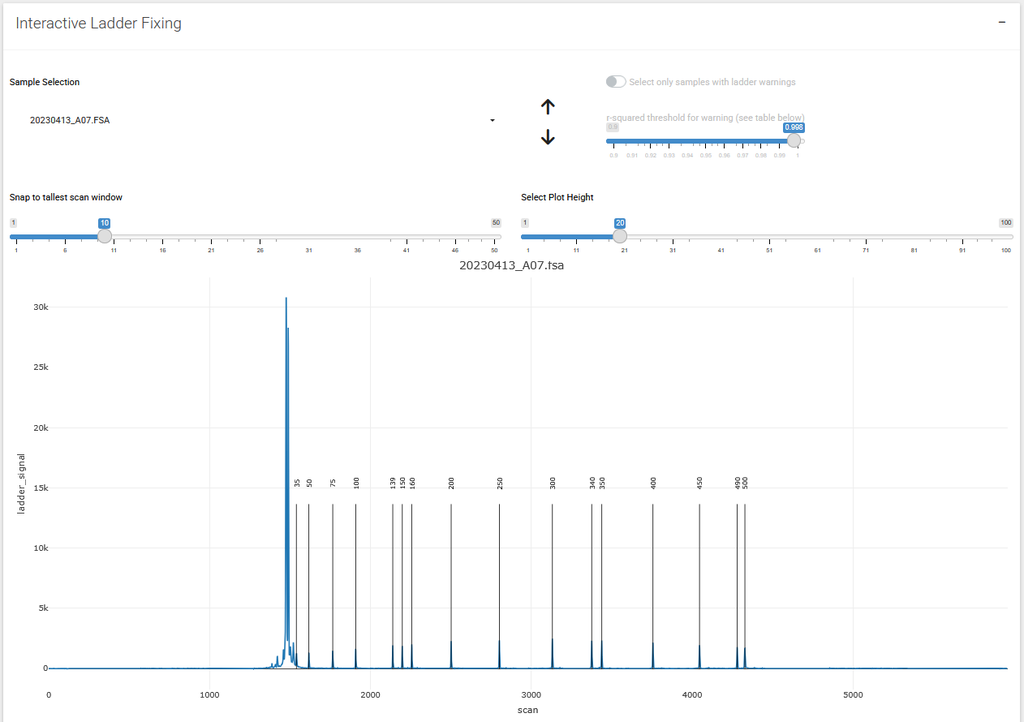

#### Select only samples with ladder warnings

Identifies samples with misaligned ladder sizes and ladder peaks. The threshold is dependent on the r-squared threshold for warning.

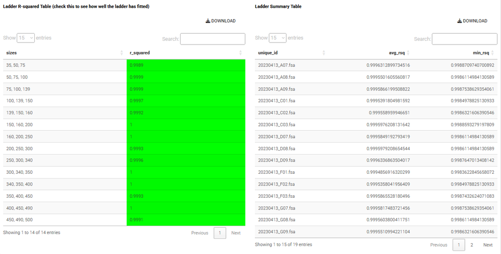

#### Ladder R-squared Table

Table of R-squared values derived from a linear regression of data signal and size for every 3 consecutive ladder sizes. Values closer to 1 indicate a better fit.

#### Ladder Summary Table

Table of the average and minimum R-squared values of the Ladder R-squared table for each sample.

#### Interactive ladder fixing

If the ladders are are not assigned correctly, you can interactively fix them.

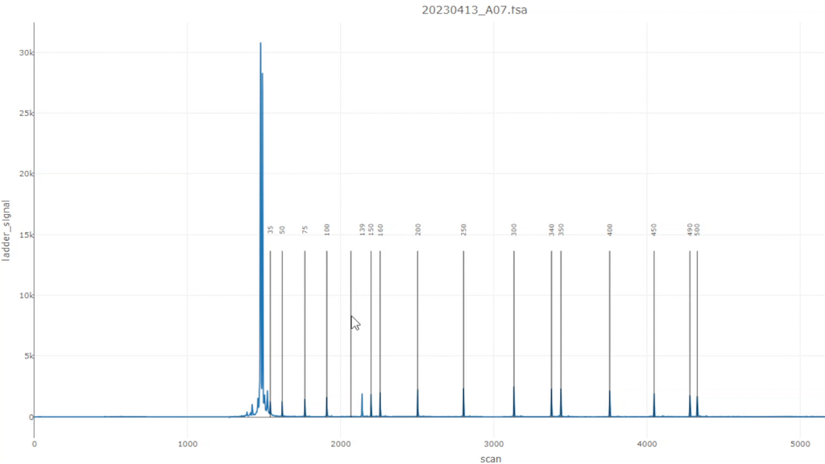